# Problem statement (Term Deposit Sale)

#### Pairplots

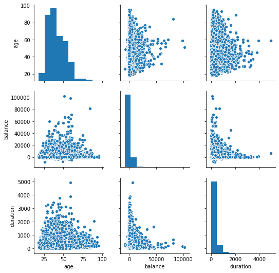

```python
sns.pairplot(TermDeposit_df[['age','balance','duration']])

# some form of correlation seem to exist between age & balance  and between age & duration
# And since age has some correction with the Target based on our visualization these independent variable do too
```

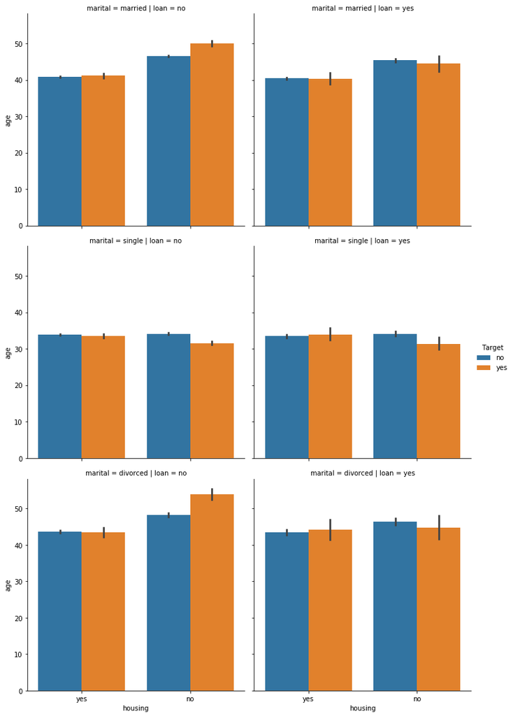

```python
sns.factorplot(x = "housing",
               y = "age",
               hue = "Target",
               col = "loan",
               row = "marital",
               data = TermDeposit_df,
               kind = "bar"
              )
```

### 3. Strategies to address the different data challenges such as data pollution, outliers and missing values.

```python
# We are going to loop though the dataframe and convert columns with an 'object' datatypes into categorical variable

# We are also going to do ordering of the categorical variable
```

## Deliverable – 2 (Prepare the data for analytics)

1. Load the data into a data-frame. The data-frame should have data and column description.
2. Ensure the attribute types are correct. If not, take appropriate actions.
3. Transform the data i.e. scale / normalize if required
4. Create the training set and test set in ration of 70:30

```python
# Lets convert the columns with an 'object' datatype into categorical variables

for feature in TermDeposit_df.columns: # Loop through all columns in the dataframe
     if TermDeposit_df[feature].dtype == 'object': # Only apply for columns with categorical strings
            TermDeposit_df[feature] = pd.Categorical(TermDeposit_df[feature]) # Replace strings with an integer
TermDeposit_df.head(10)
```

|  | age | job | marital | education | default | balance | housing | loan | contact | day | month | duration | campaign | pdays | previous | poutcome | Target |
| --- | --- | --- | --- | --- | --- | --- | --- | --- | --- | --- | --- | --- | --- | --- | --- | --- | --- |
| 0 | 58 | management | married | tertiary | no | 2143 | yes | no | unknown | 5 | may | 261 | 1 | -1 | 0 | unknown | no |
| 1 | 44 | technician | single | secondary | no | 29 | yes | no | unknown | 5 | may | 151 | 1 | -1 | 0 | unknown | no |
| 2 | 33 | entrepreneur | married | secondary | no | 2 | yes | yes | unknown | 5 | may | 76 | 1 | -1 | 0 | unknown | no |
| 3 | 47 | blue-collar | married | unknown | no | 1506 | yes | no | unknown | 5 | may | 92 | 1 | -1 | 0 | unknown | no |
| 4 | 33 | unknown | single | unknown | no | 1 | no | no | unknown | 5 | may | 198 | 1 | -1 | 0 | unknown | no |
| 5 | 35 | management | married | tertiary | no | 231 | yes | no | unknown | 5 | may | 139 | 1 | -1 | 0 | unknown | no |
| 6 | 28 | management | single | tertiary | no | 447 | yes | yes | unknown | 5 | may | 217 | 1 | -1 | 0 | unknown | no |
| 7 | 42 | entrepreneur | divorced | tertiary | yes | 2 | yes | no | unknown | 5 | may | 380 | 1 | -1 | 0 | unknown | no |
| 8 | 58 | retired | married | primary | no | 121 | yes | no | unknown | 5 | may | 50 | 1 | -1 | 0 | unknown | no |
| 9 | 43 | technician | single | secondary | no | 593 | yes | no | unknown | 5 | may | 55 | 1 | -1 | 0 | unknown | no |

```python
TermDeposit_df.info()
```

```
<class 'pandas.core.frame.DataFrame'>
RangeIndex: 45211 entries, 0 to 45210
Data columns (total 17 columns):
age          45211 non-null int64
job          45211 non-null category
marital      45211 non-null category
education    45211 non-null category
default      45211 non-null category
balance      45211 non-null int64
housing      45211 non-null category
loan         45211 non-null category
contact      45211 non-null category
day          45211 non-null int64
month        45211 non-null category
duration     45211 non-null int64
campaign     45211 non-null int64
pdays        45211 non-null int64
previous     45211 non-null int64
poutcome     45211 non-null category
Target       45211 non-null category
dtypes: category(10), int64(7)
memory usage: 2.8 MB
```

```python
print(TermDeposit_df.job.value_counts())
print(TermDeposit_df.marital.value_counts())
print(TermDeposit_df.education.value_counts())
print(TermDeposit_df.default.value_counts())
print(TermDeposit_df.housing.value_counts())
print(TermDeposit_df.loan.value_counts())
print(TermDeposit_df.contact.value_counts())
print(TermDeposit_df.month.value_counts())
print(TermDeposit_df.poutcome.value_counts())
```

```
blue-collar      9732
management       9458
technician       7597
admin.           5171
services         4154
retired          2264
self-employed    1579
entrepreneur     1487
unemployed       1303
housemaid        1240
student           938
unknown           288
Name: job, dtype: int64
married     27214
single      12790
divorced     5207
Name: marital, dtype: int64
secondary    23202
tertiary     13301
primary       6851
unknown       1857
Name: education, dtype: int64
no     44396
yes      815
Name: default, dtype: int64
yes    25130
no     20081
Name: housing, dtype: int64
no     37967
yes     7244
Name: loan, dtype: int64
cellular     29285
unknown      13020
telephone     2906
Name: contact, dtype: int64
may    13766
jul     6895
aug     6247
jun     5341
nov     3970
apr     2932
feb     2649
jan     1403
oct      738
sep      579
mar      477
dec      214
Name: month, dtype: int64
unknown    36959
failure     4901
other       1840
success     1511
Name: poutcome, dtype: int64
```

```python
# we need to keep the ordering of these categorical variable for those that have ordering especially as we know that decision trees split base on variables
# for those without ordering we are going to use dummy variable or 'one hot encoding'
```

```python
replaceStruct = {
    "marital": {"single":1, "married":2, "divorced":3},
    "education": {"primary":1, "secondary":2, "tertiary":3, "unknown":-1},
    "default": {"no":1, "yes":2},
    "housing": {"no":1, "yes":2},
    "loan": {"no":1, "yes":2},
    "contact": {"telephone":1, "cellular":2, "unknown":-1},
    #"month": {"jan":1, "feb":2, "mar":3, "apr":4, "may":5, "june":6, "jul":7, "aug":8, "sep":9, "oct":10, "nov":11, "dec":12},
    "poutcome": {"failure":1, "success":2, "other":3, "unknown":-1},
    "Target": {"no":0, "yes":1},

}
oneHotCols= ["job", "month"]
```

```python
TermDeposit_df = TermDeposit_df.replace(replaceStruct)
TermDeposit_df = pd.get_dummies(TermDeposit_df, columns = oneHotCols)
TermDeposit_df.head(10)
```

|  | age | marital | education | default | balance | housing | loan | contact | day | duration | ... | month_dec | month_feb | month_jan | month_jul | month_jun | month_mar | month_may | month_nov | month_oct | month_sep |
| --- | --- | --- | --- | --- | --- | --- | --- | --- | --- | --- | --- | --- | --- | --- | --- | --- | --- | --- | --- | --- | --- |
| 0 | 58 | 2 | 3 | 1 | 2143 | 2 | 1 | -1 | 5 | 261 | ... | 0 | 0 | 0 | 0 | 0 | 0 | 1 | 0 | 0 | 0 |
| 1 | 44 | 1 | 2 | 1 | 29 | 2 | 1 | -1 | 5 | 151 | ... | 0 | 0 | 0 | 0 | 0 | 0 | 1 | 0 | 0 | 0 |
| 2 | 33 | 2 | 2 | 1 | 2 | 2 | 2 | -1 | 5 | 76 | ... | 0 | 0 | 0 | 0 | 0 | 0 | 1 | 0 | 0 | 0 |
| 3 | 47 | 2 | -1 | 1 | 1506 | 2 | 1 | -1 | 5 | 92 | ... | 0 | 0 | 0 | 0 | 0 | 0 | 1 | 0 | 0 | 0 |
| 4 | 33 | 1 | -1 | 1 | 1 | 1 | 1 | -1 | 5 | 198 | ... | 0 | 0 | 0 | 0 | 0 | 0 | 1 | 0 | 0 | 0 |
| 5 | 35 | 2 | 3 | 1 | 231 | 2 | 1 | -1 | 5 | 139 | ... | 0 | 0 | 0 | 0 | 0 | 0 | 1 | 0 | 0 | 0 |
| 6 | 28 | 1 | 3 | 1 | 447 | 2 | 2 | -1 | 5 | 217 | ... | 0 | 0 | 0 | 0 | 0 | 0 | 1 | 0 | 0 | 0 |
| 7 | 42 | 3 | 3 | 2 | 2 | 2 | 1 | -1 | 5 | 380 | ... | 0 | 0 | 0 | 0 | 0 | 0 | 1 | 0 | 0 | 0 |
| 8 | 58 | 2 | 1 | 1 | 121 | 2 | 1 | -1 | 5 | 50 | ... | 0 | 0 | 0 | 0 | 0 | 0 | 1 | 0 | 0 | 0 |
| 9 | 43 | 1 | 2 | 1 | 593 | 2 | 1 | -1 | 5 | 55 | ... | 0 | 0 | 0 | 0 | 0 | 0 | 1 | 0 | 0 | 0 |

10 rows × 39 columns

```python
TermDeposit_df.info() # everything is now numeric
```

```
<class 'pandas.core.frame.DataFrame'>
RangeIndex: 45211 entries, 0 to 45210
Data columns (total 39 columns):
age                  45211 non-null int64
marital              45211 non-null int64
education            45211 non-null int64
default              45211 non-null int64
balance              45211 non-null int64
housing              45211 non-null int64
loan                 45211 non-null int64
contact              45211 non-null int64
day                  45211 non-null int64
duration             45211 non-null int64
campaign             45211 non-null int64
pdays                45211 non-null int64
previous             45211 non-null int64
poutcome             45211 non-null int64
Target               45211 non-null int64
job_admin.           45211 non-null uint8
job_blue-collar      45211 non-null uint8
job_entrepreneur     45211 non-null uint8
job_housemaid        45211 non-null uint8
job_management       45211 non-null uint8
job_retired          45211 non-null uint8
job_self-employed    45211 non-null uint8
job_services         45211 non-null uint8
job_student          45211 non-null uint8
job_technician       45211 non-null uint8
job_unemployed       45211 non-null uint8
job_unknown          45211 non-null uint8
month_apr            45211 non-null uint8
month_aug            45211 non-null uint8
month_dec            45211 non-null uint8
month_feb            45211 non-null uint8
month_jan            45211 non-null uint8
month_jul            45211 non-null uint8
month_jun            45211 non-null uint8
month_mar            45211 non-null uint8
month_may            45211 non-null uint8
month_nov            45211 non-null uint8
month_oct            45211 non-null uint8
month_sep            45211 non-null uint8
dtypes: int64(15), uint8(24)
memory usage: 6.2 MB
```

```python
# Let split our data
X = TermDeposit_df.drop("Target" , axis=1)
y = TermDeposit_df.pop("Target")
```

```python
X_train, X_test, y_train, y_test = train_test_split(X, y, test_size=.30, random_state=1)
```

## Deliverable – 3 (create the ensemble model)

1. Write python code using scikitlearn, pandas, numpy and others in Jupyter notebook to train and test the ensemble model.
2. First create a model using standard classification algorithm. Note the model performance.
3. Use appropriate algorithms and explain why that algorithm in the comment lines.
4. Evaluate the model. Use confusion matrix to evaluate class level metrics i.e..Precision and recall. Also reflect the overall score of the model.
5. Advantages and disadvantages of the algorithm.

```python
from sklearn.naive_bayes import GaussianNB # using Gaussian algorithm from Naive Bayes
```

```python
# creating a model using standard classification algorithm
diab_model = GaussianNB()
diab_model.fit(X_train, y_train.ravel())
```

```
GaussianNB(priors=None, var_smoothing=1e-09)
```

```python
### Performance of our model with training data

diab_train_predict = diab_model.predict(X_train)

print("Model Accuracy: {0:.4f}".format(metrics.accuracy_score(y_train, diab_train_predict)))
print()
```

```
Model Accuracy: 0.8478
```

```python
### Performance of our model with testing data
diab_test_predict = diab_model.predict(X_test)

print("Model Accuracy: {0:.4f}".format(metrics.accuracy_score(y_test, diab_test_predict)))
print()
```

```
Model Accuracy: 0.8419
```

```python
# NB Confusion matrix and Classification Report
```

```
Confusion Matrix
```

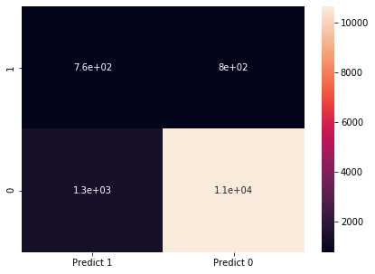

```python
print("Confusion Matrix")
cm=metrics.confusion_matrix(y_test, diab_test_predict, labels=[1, 0])

df_cm = pd.DataFrame(cm, index = [i for i in ["1","0"]],
                  columns = [i for i in ["Predict 1","Predict 0"]])
plt.figure(figsize = (7,5))
sns.heatmap(df_cm, annot=True)
```

```python
print("Classification Report")
print(metrics.classification_report(y_test, diab_test_predict, labels=[1, 0]))
```

```
Classification Report
              precision    recall  f1-score   support

           1       0.36      0.49      0.41      1551
           0       0.93      0.89      0.91     12013

    accuracy                           0.84     13564
   macro avg       0.64      0.69      0.66     13564
weighted avg       0.87      0.84      0.85     13564
```

```python
# Reason why this algorithm was used is If the independence assumption holds then it works
# more efficiently than other algorithms.
# It also requires less training data. It is highly scalable. It can make probabilistic predictions.

# And the grand reason why this algarithm was used is that Naive Bays is truely a base algarithm,
# below whose performance no other algorithm should go for our model to be acceptable

# We cannot rely solely on this model because of the NB algaorithm which is very base and weak
# Its disadvantage is that it assumes that the features are independent, which in our case is not true; because
# 'age' ,'job', 'education' and 'balance' seems to be related or dependent.

# This is evident on it F1-Score which is the harmonic mean of precision and recall values for a classification problem
# And some of its F1-Scores is so low
```

#### Building ensemble model to compare the results with the base model

```python
#Build Decision Tree Model

#We will build our model using the DecisionTreeClassifier function. Using default 'gini' criteria to split. Other option include 'entropy'


dTree = DecisionTreeClassifier(criterion = 'gini', random_state=1)
dTree.fit(X_train, y_train)
```

```
DecisionTreeClassifier(class_weight=None, criterion='gini', max_depth=None,
                       max_features=None, max_leaf_nodes=None,
                       min_impurity_decrease=0.0, min_impurity_split=None,
                       min_samples_leaf=1, min_samples_split=2,
                       min_weight_fraction_leaf=0.0, presort=False,
                       random_state=1, splitter='best')
```

```python
#Scoring our Decision Tree
print(dTree.score(X_train, y_train))
print(dTree.score(X_test, y_test))
```

```
1.0
0.8737835446770864
```

```python
# The above shown overfittng on the training data i.e. 100% but perform lower on the test data 87%
```

```python
# Visualizing the Decision Tree

train_char_label = ['No', 'Yes']
Term_Tree_File = open('term_tree.dot', 'w')
dot_data = tree.export_graphviz(dTree, out_file = Term_Tree_File, feature_names = list(X_train), class_names = list(train_char_label))
Term_Tree_File.close()
```

```python
# works only if 'dot' command works on your machine

retCode = system("dot -Tpng term_tree.dot -o term_tree.png")
if (retCode>0):
    print("system command returning error: "+str(retCode))
else:
    display (Image("term_tree.png"))
```

```
system command returning error: 1
```

```python
# graphviz is not working on my computer
```

## Deliverable – 4 (Tuning the model)

1. Discuss some of the key hyper parameters available for the selected algorithm. What values did you initialize these parameters to?

#### Reducing overfitting (Regularization)

```python
dTreeR = DecisionTreeClassifier(criterion = 'gini', max_depth= 3, random_state=1)
dTreeR.fit(X_train, y_train)
print(dTreeR.score(X_train, y_train))
print(dTreeR.score(X_test, y_test))
```

```
0.8949979460928366
0.8969330580949573
```

```python
# The tree above is a better fit, performing well with train data as well as test data
# And it performs better than our earlier base model built with Naive Baye's algorithm
```

```python
# The hyperparameters available for our decision tree are criterion, max_depth and random_state
# I initialized criterion to gini (as against entropy), max_depth to 3 (to take care of overfitting) and random_state to 1 (for reproduction purposes)
```

```python
# The feature importance are:  'duration', 'age', 'contact' and 'poutcome'
print (pd.DataFrame(dTreeR.feature_importances_, columns = ["Imp"], index = X_train.columns))
```

```
                        Imp
age                0.052318
marital            0.000000
education          0.000000
default            0.000000
balance            0.000000
housing            0.000000
loan               0.000000
contact            0.034871
day                0.000000
duration           0.592041
campaign           0.000000
pdays              0.000000
previous           0.000000
poutcome           0.320769
job_admin.         0.000000
job_blue-collar    0.000000
job_entrepreneur   0.000000
job_housemaid      0.000000
job_management     0.000000
job_retired        0.000000
job_self-employed  0.000000
job_services       0.000000
job_student        0.000000
job_technician     0.000000
job_unemployed     0.000000
job_unknown        0.000000
month_apr          0.000000
month_aug          0.000000
month_dec          0.000000
month_feb          0.000000
month_jan          0.000000
month_jul          0.000000
month_jun          0.000000
month_mar          0.000000
month_may          0.000000
month_nov          0.000000
month_oct          0.000000
month_sep          0.000000
```

```
0.8969330580949573
```

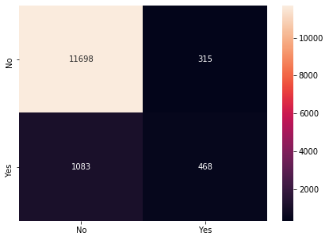

```python
# Confusion matrix

print(dTreeR.score(X_test, y_test))
y_predict =  dTreeR.predict(X_test)

cm=metrics.confusion_matrix(y_test, y_predict, labels=[0, 1])

df_cm = pd.DataFrame(cm, index = [i for i in ["No", "Yes"]],
                     columns = [i for i in ["No", "Yes"]])
plt.figure(figsize = (7,5))
sns.heatmap(df_cm, annot=True, fmt='g')
```

```python
# This tuned tree has a TP = 468 and TN = 11698 (WE CORRECTLY PREDICTED THAT THESE WILL NOT SUBSCRIBE TO TERM
# DEPOSIT AND THEY DID NOT, SO THE BUSINESS ANALYSIS HERE IS THAT WE HAVE IDENTIFIED THEM AND CAN CHASE
# PERHAPS WORKING AROUND SOME KNOWN HINDRANCES TILL THEY DEPOSIT)

# BY THE WAY OUR ACCURACY OF 0.896 (OR 90%) IS ENCOURAGING
```

#### Let do Ensemble RamdomForest Classifier

This way we won't have to specify max_depth i.e. it is not susceptible to overfitting

```python
from sklearn.ensemble import RandomForestClassifier
rfcl = RandomForestClassifier(n_estimators=50, random_state=1, max_features=12)
rfcl = rfcl.fit(X_train, y_train)
```

```
0.907770569153642
```

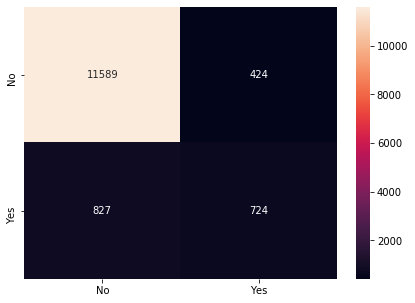

```python
y_predict =  rfcl.predict(X_test)
print(rfcl.score(X_test, y_test))


cm=metrics.confusion_matrix(y_test, y_predict, labels=[0, 1])

df_cm = pd.DataFrame(cm, index = [i for i in ["No", "Yes"]],
                     columns = [i for i in ["No", "Yes"]])
plt.figure(figsize = (7,5))
sns.heatmap(df_cm, annot=True, fmt='g')
```

```python
# The algorithm goes to a complex depth and yet produces the best results with a better accuracy of 91%.
# The hyperparameter used here are: n_estimators=50, random_state=1, max_features=12 (leaving out max_depth which will lower its accuracy if a low number is set)
```